# Designing an Interdisciplinary Data Science Minor

Washington & Jefferson College, John Ladd & Rebecca Rapp

https://jrladd.com/slides/sigcse2025.html

# Our starting point

Computing & Information Studies Major w/ Data Science Emphasis

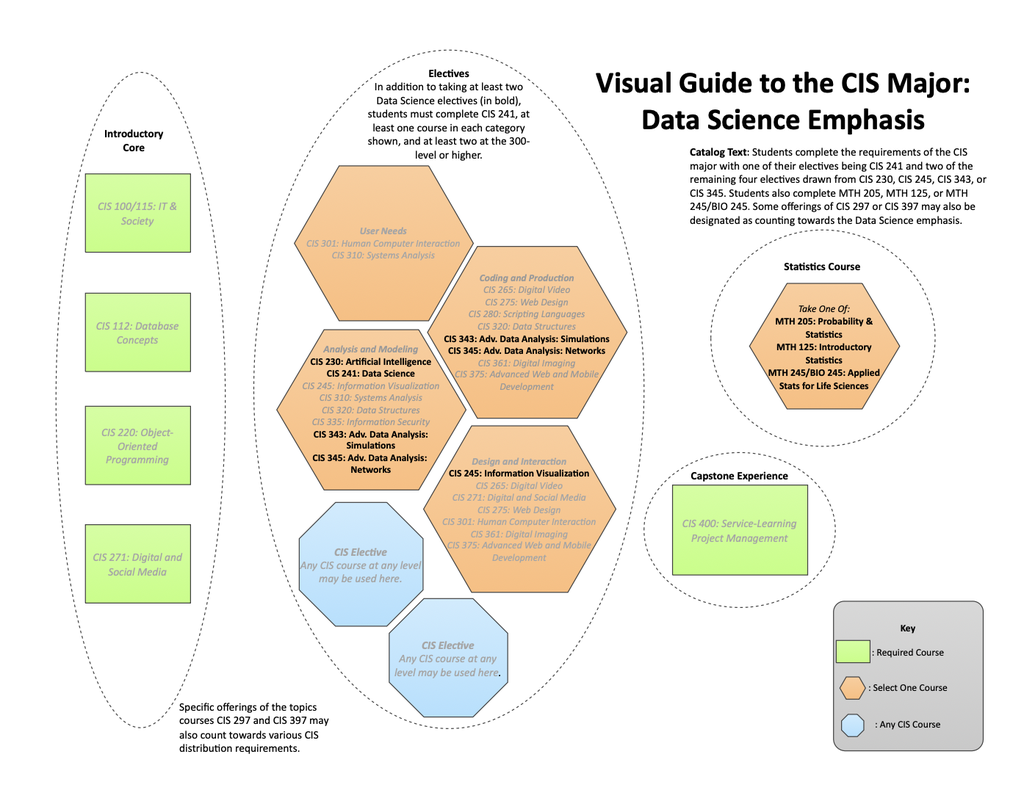

- CIS Minor
- Computational Science Concentration

[figure not shown]

# Why a data science minor?

- DS Emphasis only available to existing CIS majors
- many non-CIS majors were already voluntarily taking data science courses, encouraged by major advisors, most frequently:
  - business & economics
  - biology
  - environmental science
- W&J’s two course of study requirement

## A data science minor is a natural fit for a liberal arts college

- Pairs well with most/all majors
- Already an interdisciplinary, applied field
- Can focus on teaching data science *as a liberal art*

# Structuring the Program

## Three required core courses

- CIS 112 Database Concepts
- CIS 241 Intro to Data Science
- Statistics course (MTH 125, MTH 205, or MTH/BIO 245)

## CIS 112 Database Concepts

- covers data collection, organization
- discusses user needs and user-centered DB design
- data management concepts w/ SQL
- also a core course for the CIS major

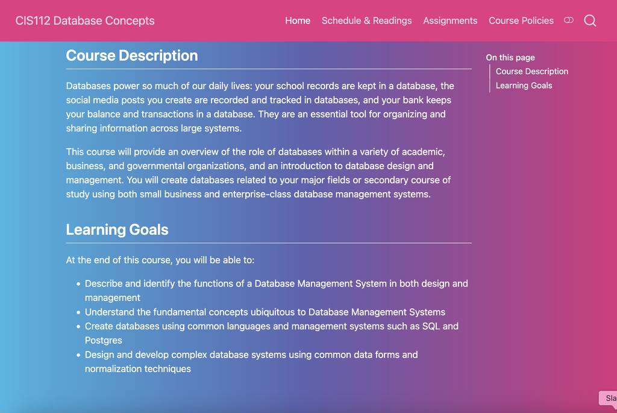

## CIS 241 Intro to Data Science

- covers data analysis and statistical modeling
- focuses on applying data science to wide variety of fields/areas of study
- not required for the CIS major but a popular introductory course
- taught in Python with Pandas/sklearn

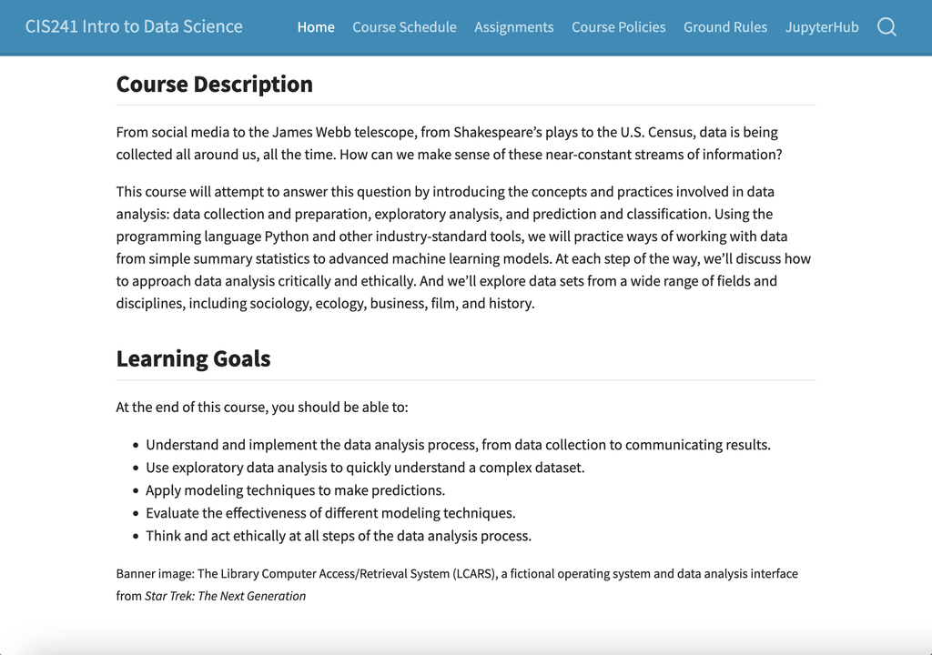

## Statistics requirement

Students take one of the following:

- MTH 125 Introductory Statistics
- MTH 205 Probability & Statistics (Recommended)
- MTH 245/BIO 245 Applied Stats for Life Sciences

## Three more elective courses

- Two must be CIS courses
- One must be a Data Project course (see below)
- One can (and should!) be outside of CIS

## CIS Electives

- CIS 220 Object-Oriented Programming
- CIS 230 Artificial Intelligence
- CIS 245 Information Visualization
- *CIS 343 Adv. Data Analysis: Simulations*
- *CIS 345 Adv. Data Analysis: Networks*

## Selected non-CIS Electives (16 and counting)

- BUS 326 Business Analytics
- CHM 270 Analytical Chemistry
- ECN 440 Econometrics
- MTH 330 Introduction to Graph Theory
- PHL 342 Experimental Philosophy
- PHY 332 Electronics
- POL 340 Research Methods
- PSY 4XX Advanced Lab

## Project Courses

- Requires sustained, independent work by students on a data set of their choosing
- Decided in conversation with faculty from different departments
- Meant to ensure students have experience completing a data science project from start to finish
- Students only need to complete 1, and both advanced CIS data courses count

# Challenges

- Continuing to coordinate and accommodate faculty/courses from a large number of disciplines
- Helping students who take DS courses at different times in their college careers
- Making students see that DS enhances the study of *any* discipline
- Getting the word out to students not in a major that already has an elective
- Showing the ways quantitative and qualitative analysis complement each other

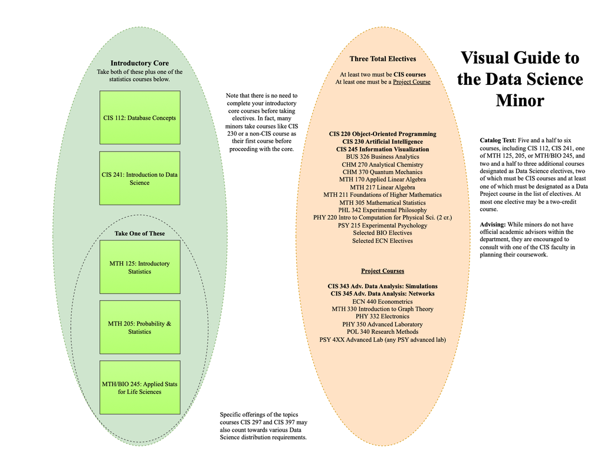